# Top-N Recommendation System (CW2 Prototype)

**Name:** 23050262 Sujal Parajuli

Implementing a Top-N recommender system using:

- **Popularity baseline** (cold-start fallback)
- **Item–Item similarity** (Item-based collaborative filtering)
- **TruncatedSVD** (latent factor model)

Producing:

- **Precision@10, Recall@10, NDCG@10** results table
- A comparison **bar chart** for the three methods
- A notebook **user selection interface** to generate recommendations

## Imports and setup

```python
import math

import pandas as pd
import numpy as np
import matplotlib.pyplot as plt

from sklearn.decomposition import TruncatedSVD
from sklearn.metrics.pairwise import cosine_similarity
```

## Loading the Filtered CSV

Reading the cleaned and filtered dataset generated from preprocessing.

```python
# Loaded the cleaned dataset
df = pd.read_csv("cleaned_filtered_reviews_metadata.csv")
```

```python
# Displaying the first few rows to confirm the data was loaded correctly
print("Rows:", len(df))
print("Columns:", df.shape[1])
df.head()
```

```
Rows: 10991
Columns: 25
```

|  | rating | title_x | text | images_x | asin | parent_asin | user_id | timestamp | helpful_vote | verified_purchase | ... | description | price | images_y | videos | store | categories | details | bought_together | subtitle | author |
| --- | --- | --- | --- | --- | --- | --- | --- | --- | --- | --- | --- | --- | --- | --- | --- | --- | --- | --- | --- | --- | --- |
| 0 | 5 | Excellent! | I love these. They even come with a carry case... | [] | B01G8JO5F2 | B01G8JO5F2 | AFKZENTNBQ7A7V7UXW5JJI6UGRYQ | 2018-04-07 09:23:37.534 | 0 | True | ... | [] | 24.96 | [{'thumb': 'https://m.media-amazon.com/images/... | [] | Senso | ['Electronics', 'Headphones, Earbuds & Accesso... | {'Product Dimensions': '4.9 x 4.7 x 1.3 inches... | NaN | NaN | NaN |
| 1 | 5 | Great Fan! I’m a FAN! | Light weight, quiet and totally awesome!!! It ... | [] | B072DSHKCH | B07CML419K | AGCI7FAH4GL5FI65HYLKWTMFZ2CQ | 2021-11-21 19:28:01.041 | 0 | True | ... | [] | 15.99 | [{'thumb': 'https://m.media-amazon.com/images/... | [{'title': 'Good air, loud rattle', 'url': 'ht... | Fancii | ['Electronics', 'Computers & Accessories', 'Co... | {'Brand': 'Fancii', 'Color': 'Black', 'Electri... | NaN | NaN | NaN |
| 2 | 5 | Love the headphones - great range | These are fantastic headphones and I love that... | [] | B07BND376H | B09S6Y5BRG | AGCI7FAH4GL5FI65HYLKWTMFZ2CQ | 2018-11-04 18:40:31.659 | 9 | True | ... | [] | 19.99 | [{'thumb': 'https://m.media-amazon.com/images/... | [] | Otium | ['Electronics', 'Headphones, Earbuds & Accesso... | {'Brand': 'Otium', 'Model Name': 'U18', 'Color... | NaN | NaN | NaN |
| 3 | 5 | Five Stars | pretty good for the price. | [] | B002HWRZ2K | B01LW71IBJ | AGCI7FAH4GL5FI65HYLKWTMFZ2CQ | 2016-02-29 19:02:51.000 | 0 | True | ... | [] | NaN | [{'thumb': 'https://m.media-amazon.com/images/... | [{'title': 'Logitech Z313 2.1 Multimedia Speak... | Logitech | ['Electronics', 'Portable Audio & Video', 'Por... | {'Brand': 'Logitech', 'Series': 'Z313', 'Power... | NaN | NaN | NaN |
| 4 | 5 | BUY THIS THANG | yes.. so good. just buy it. my favorite featu... | [] | B00WK47VEW | B017T99JPG | AGCI7FAH4GL5FI65HYLKWTMFZ2CQ | 2016-02-29 18:59:25.000 | 0 | True | ... | ["It's the small speaker with the big, big voi... | 170.00 | [{'thumb': 'https://m.media-amazon.com/images/... | [{'title': 'Not a speaker, Just a base Magnifi... | Bose | ['Electronics', 'Portable Audio & Video', 'Por... | {'Product Dimensions': '7.1 x 2.3 x 2 inches',... | NaN | NaN | NaN |

5 rows × 25 columns

```python
# Converting timestamp to datetime so resample/time-split works
df["timestamp"] = pd.to_datetime(df["timestamp"], errors="coerce")
df = df.dropna(subset=["timestamp"]).copy()
```

## ASIN-to-title mapping

Creating a mapping for displaying product titles instead of ASIN codes.

```python
asin_to_product = (
    df[["parent_asin", "title_y"]]
    .drop_duplicates()
    .set_index("parent_asin")["title_y"]
    .to_dict())
```

## Exploratory visualizations

Showing dataset patterns before training:

- Rating distribution
- Category distribution
- Reviews over time
- Price vs rating
- Correlation heatmap (numeric features)
- Interaction distributions (users/items)

### Rating distribution (bar chart)

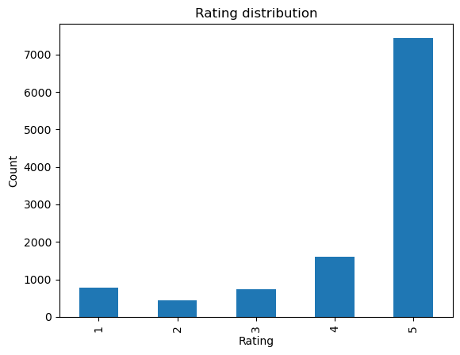

```python
df["rating"].value_counts().sort_index().plot(kind="bar")
plt.title("Rating distribution")
plt.xlabel("Rating")
plt.ylabel("Count")
plt.show()
```

### Category distribution (pie chart)

Showing the top categories and grouping the rest as **Other**.

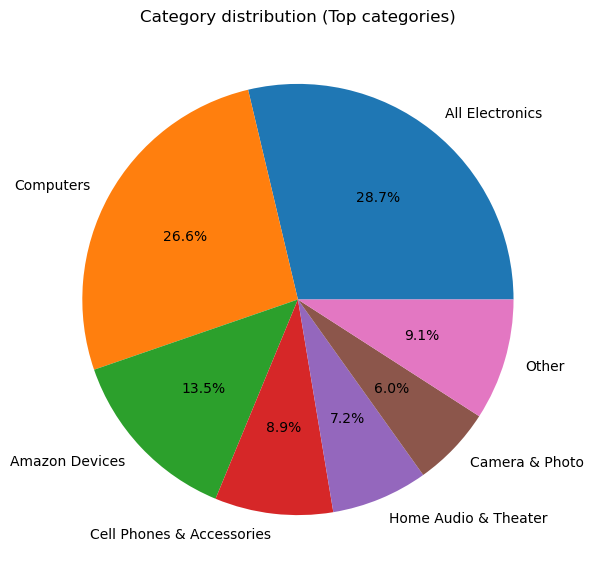

```python
cat_counts = df["main_category"].value_counts()
top_k = 6

top_cats = cat_counts.head(top_k)
other = cat_counts.iloc[top_k:].sum()

pie_data = top_cats.copy()
pie_data.loc["Other"] = other

plt.figure(figsize=(7, 7))
plt.pie(pie_data.values, labels=pie_data.index, autopct="%1.1f%%")
plt.title("Category distribution (Top categories)")
plt.show()
```

### Reviews over time (line chart)

Grouping reviews by month to show activity trends.

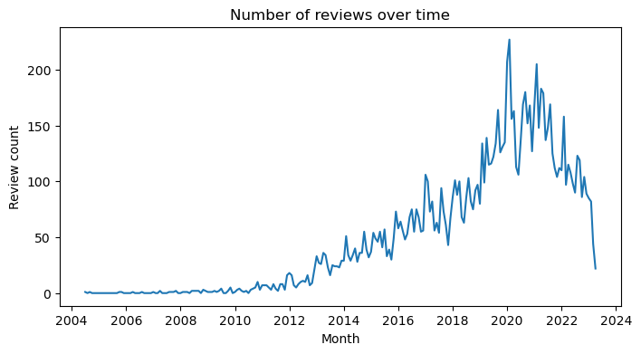

```python
# Grouping review records by month using the timestamp column
monthly = df.set_index("timestamp").resample("ME").size()

# Displaying a line graph to show how review activity changes over time
plt.figure(figsize=(8, 4))
plt.plot(monthly.index, monthly.values)
plt.title("Number of reviews over time")
plt.xlabel("Month")
plt.ylabel("Review count")
plt.show()
```

### Price vs rating (scatter plot)

Visualizing whether price has any visible relationship with rating.

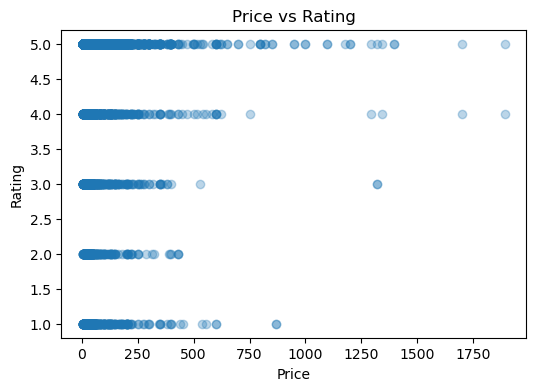

```python
# Keeping only rows where both price and rating are present (not NaN)
tmp = df.dropna(subset=["price", "rating"])
# Displaying a scatter plot to visualize the relationship between price and rating
plt.figure(figsize=(6, 4))
plt.scatter(tmp["price"], tmp["rating"], alpha=0.3)
plt.title("Price vs Rating")
plt.xlabel("Price")
plt.ylabel("Rating")
plt.show()
```

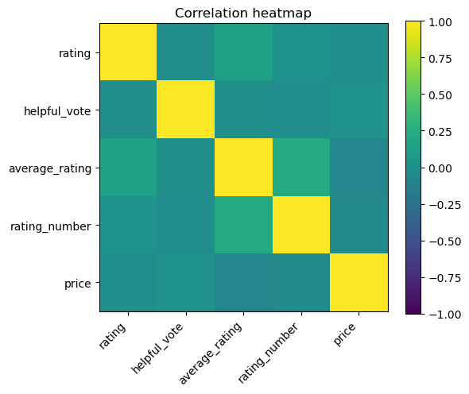

```python
# Calculate the correlation matrix for the selected numeric columns
corr = df[["rating", "helpful_vote", "average_rating", "rating_number", "price"]].corr()

# Create a new figure (plot area) with a fixed size
plt.figure(figsize=(6, 5))

# Display the correlation matrix as a heatmap (here, colors shows correlation strength)
plt.imshow(corr, interpolation="nearest", vmin=-1, vmax=1)

# Set x-axis labels (column names) and rotate them for readability
plt.xticks(range(len(corr.columns)), corr.columns, rotation=45, ha="right")

# Set y-axis labels (column names)
plt.yticks(range(len(corr.columns)), corr.columns)

# Add a title to the heatmap
plt.title("Correlation heatmap")

# Add a color scale bar to show what colors mean (-1 to 1)
plt.colorbar()

# Adjust spacing so labels don't get cut off
plt.tight_layout()

# Show the plot
plt.show()
```

```python
# shows the correlation numbers with only 3 digits after the decimal to make them easier to read
corr.round(3)
```

|  | rating | helpful_vote | average_rating | rating_number | price |
| --- | --- | --- | --- | --- | --- |
| rating | 1.000 | -0.005 | 0.146 | 0.021 | -0.020 |
| helpful_vote | -0.005 | 1.000 | -0.015 | -0.021 | 0.030 |
| average_rating | 0.146 | -0.015 | 1.000 | 0.225 | -0.078 |
| rating_number | 0.021 | -0.021 | 0.225 | 1.000 | -0.053 |
| price | -0.020 | 0.030 | -0.078 | -0.053 | 1.000 |

### User interaction count distribution (histogram)

Showing how many interactions each user has.

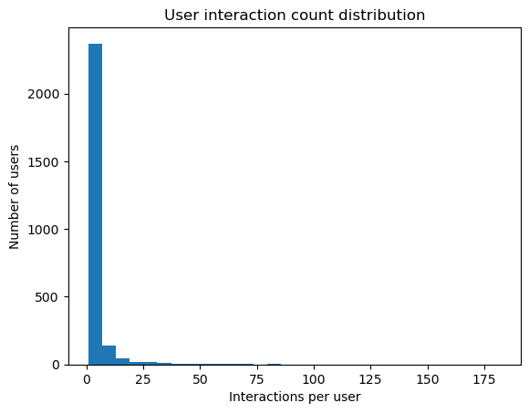

```python
# Count how many interactions (rows) each user has
user_counts = df.groupby("user_id").size()

# Plot a histogram of interaction counts (30 bins)
user_counts.plot(kind="hist", bins=30)

# Add a title to the chart
plt.title("User interaction count distribution")

# Label the x-axis (interactions per user)
plt.xlabel("Interactions per user")

# Label the y-axis (number of users in each bin)
plt.ylabel("Number of users")
plt.show()
```

### Item interaction count distribution (histogram)

Showing how many interactions each item has.

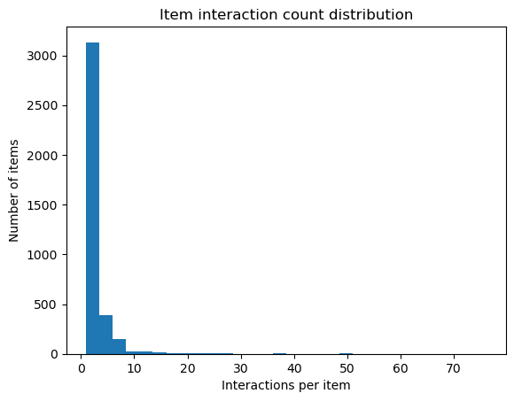

```python
item_counts = df.groupby("parent_asin").size()
item_counts.plot(kind="hist", bins=30)
plt.title("Item interaction count distribution")
plt.xlabel("Interactions per item")
plt.ylabel("Number of items")
plt.show()
```

### Top 10 items by interaction count (horizontal bar chart)

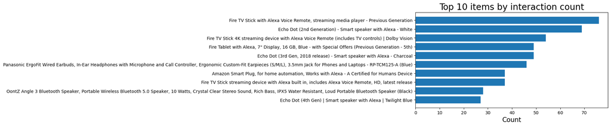

```python
# Count how many times each product (parent_asin) appears, then keep the top 10 most interacted items
top_items = df.groupby("parent_asin").size().sort_values(ascending=False).head(10)

# Convert ASIN codes into product titles (if missing, it will show the ASIN itself)
top_titles = [asin_to_product.get(a, a) for a in top_items.index]

# Create the plot area
plt.figure(figsize=(8, 4))

# Plot a horizontal bar chart (reversed so the biggest bar appears at the top)
plt.barh(top_titles[::-1], top_items.values[::-1])

# Make title and labels bigger + bold
plt.title("Top 10 items by interaction count",  fontsize=20)
plt.xlabel("Count", fontsize=15)
plt.show()
```

## Time-aware train/test split

Holding out the most recent interaction per user for offline evaluation.

```python
df_sorted = df.sort_values(["user_id", "timestamp"])
test_idx = df_sorted.groupby("user_id").tail(1).index

train_df = df_sorted.drop(index=test_idx).copy()
test_df = df_sorted.loc[test_idx].copy()

print("Train rows:", len(train_df))
print("Test rows:", len(test_df))
```

```
Train rows: 8359
Test rows: 2632
```

## Building the interaction matrix (training data)

Creating a user–item matrix of mean ratings.

```python
interaction_matrix = train_df.pivot_table(
    index="user_id",
    columns="parent_asin",
    values="rating",
    aggfunc="mean"
).fillna(0).astype(np.float32)

users = interaction_matrix.index.to_list()
items = interaction_matrix.columns.to_list()
item_index = {asin: i for i, asin in enumerate(items)}

print("Interaction matrix shape (users and items):", interaction_matrix.shape)
```

```
Interaction matrix shape (users and items): (1772, 3501)
```

## User–Item Sparsity Heatmap

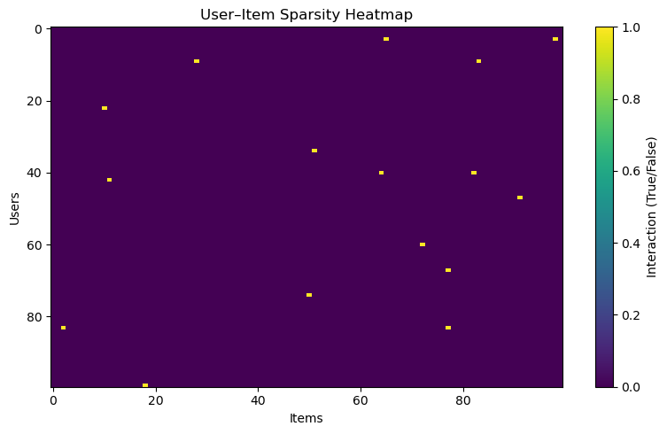

```python
# Taking a small sample of users and items so the heatmap stays readable
sample_users = interaction_matrix.index[:100]     # first 100 users
sample_items = interaction_matrix.columns[:100]   # first 100 items

# Extracting the sampled part of the matrix
sample_mat = interaction_matrix.loc[sample_users, sample_items]

# Ploting the sparsity pattern
plt.figure(figsize=(8, 5))
plt.imshow(sample_mat.values > 0, aspect="auto")
plt.title("User–Item Sparsity Heatmap")
plt.xlabel("Items")
plt.ylabel("Users")
plt.colorbar(label="Interaction (True/False)")
plt.tight_layout()
plt.show()
```

## Model 1: Popularity baseline

Ranking items by how frequently they appear in the training data.

```python
popularity_list = (
    train_df.groupby("parent_asin")
    .size()
    .sort_values(ascending=False)
    .index
    .tolist()
)

def recommend_popularity(user_id, N=10):
        # Removing already-seen items when the user exists
    if user_id in interaction_matrix.index:
        seen = set(interaction_matrix.loc[user_id][lambda x: x > 0].index)
    else:
        seen = set()
    recs = [a for a in popularity_list if a not in seen][:N]
    return recs
```

## Model 2: Item–Item similarity

Computing cosine similarity between item vectors.

```python
# Computing item vectors (items and users)
item_vectors = interaction_matrix.T.values

# Computing cosine similarity matrix (items and items)
sim_matrix = cosine_similarity(item_vectors)

# Creating a DataFrame
item_similarity_df = pd.DataFrame(sim_matrix, index=items, columns=items)
```

```python
# Checking how the data frame looks
item_similarity_df.head()
```

|  | 0062970704 | 0345803507 | B00000J1QR | B00003006K | B00004TBLW | B00005T406 | B000065BP9 | B000065UQA | B000066R6M | B000067REN | ... | B0CBWV3Q8B | B0CCD3VDQN | B0CCDMQZM7 | B0CCQHH8Z6 | B0CD7L5PKM | B0CDC4RFXQ | B0CDCF3MLP | B0CDLVKXF7 | B0CDVW2RNG | B0CGLRJHDK |
| --- | --- | --- | --- | --- | --- | --- | --- | --- | --- | --- | --- | --- | --- | --- | --- | --- | --- | --- | --- | --- | --- |
| 0062970704 | 1.0 | 0.0 | 0.0 | 0.0 | 0.0 | 0.0 | 0.0 | 0.0 | 0.0 | 0.0 | ... | 0.0 | 0.0 | 0.0 | 0.0 | 0.0 | 0.0 | 0.0 | 0.0 | 0.0 | 0.0 |
| 0345803507 | 0.0 | 1.0 | 0.0 | 0.0 | 0.0 | 0.0 | 0.0 | 0.0 | 0.0 | 0.0 | ... | 0.0 | 0.0 | 0.0 | 0.0 | 0.0 | 0.0 | 0.0 | 0.0 | 0.0 | 0.0 |
| B00000J1QR | 0.0 | 0.0 | 1.0 | 0.0 | 0.0 | 0.0 | 0.0 | 0.0 | 0.0 | 0.0 | ... | 0.0 | 0.0 | 0.0 | 0.0 | 0.0 | 0.0 | 0.0 | 0.0 | 0.0 | 0.0 |
| B00003006K | 0.0 | 0.0 | 0.0 | 1.0 | 0.0 | 0.0 | 0.0 | 0.0 | 0.0 | 0.0 | ... | 0.0 | 0.0 | 0.0 | 0.0 | 0.0 | 0.0 | 0.0 | 0.0 | 0.0 | 0.0 |
| B00004TBLW | 0.0 | 0.0 | 0.0 | 0.0 | 1.0 | 0.0 | 0.0 | 0.0 | 0.0 | 0.0 | ... | 0.0 | 0.0 | 0.0 | 0.0 | 0.0 | 0.0 | 0.0 | 0.0 | 0.0 | 0.0 |

5 rows × 3501 columns

### Similar items for a selected product

```python
# Selecting the product (ASIN) for finding similar items
target_asin = "0062970704"

# Checking if the target ASIN exists in the similarity matrix
if target_asin in item_similarity_df.columns:

    # Getting similarity scores for the target item, sorting highest to lowest, and taking the top 10
    similar_products = item_similarity_df[target_asin].sort_values(ascending=False).head(10)

    # Printing the target product name (using the mapping) as a header
    print(f"Top 10 Most Similar Products to {asin_to_product.get(target_asin, target_asin)}:")

    # Looping through each similar ASIN and its similarity score
    for asin, similarity in similar_products.items():

        # Converting the ASIN into a readable product name (showing 'Unknown Product' if missing)
        product_name = asin_to_product.get(asin, "Unknown Product")

        # Printing the product name and similarity score (formatted to 4 decimals)
        print(f"Product: {product_name}, Similarity: {similarity:.4f}")

# Printing a message when the target ASIN is not found in the similarity matrix
else:
    print("Target ASIN not found in similarity matrix.")
```

```
Top 10 Most Similar Products to Strange Planet (Strange Planet Series):
Product: Strange Planet (Strange Planet Series), Similarity: 1.0000
Product: TV Mount, Full Motion TV Wall Mount Swivel Tilt for 26-60 Inch TVs and Monitors up to 70lbs, Single Stud Corner Outdoor Wall Mount TV Bracket Articulating Extension Leveling Max VESA 400X400mm, Similarity: 0.7071
Product: 2-Year Accident Protection for Echo Dot (2016 release), Similarity: 0.7071
Product: SAMSUNG Galaxy S9+ Factory Unlocked Smartphone 64GB - Midnight Black, Similarity: 0.6860
Product: Outdoor Bluetooth Speaker with Flame Atmosphere, Electronics Gifts for Men, Women, Cool Gadgets for Porch Garden Parties, BT5.0, 5W Stereo Sound, Waterproof Wireless Speaker with Led Torch Light, Similarity: 0.6325
Product: BOSS Audio Systems B9351WRC Double Din, Touchscreen, Bluetooth, DVD CD MP3 USB SD AM FM Car Stereo, 6.2 Inch Digital LCD Monitor, Wireless Remote, Wireless Rear License Plate Camera., Similarity: 0.6325
Product: Trisonic Telephone Extension Cord Phone Cable Foot, 50ft, White, Similarity: 0.5657
Product: Dolica AX600B250 60-Inch Aluminum Alloy Proline Traveler Edition Tripod with High Performance Ball Head (Black), Similarity: 0.5657
Product: Belkin Power Strip Surge Protector with 8 Outlets, 6 ft Long Flat Plug Heavy Duty Extension Cord + Overload Protection for Home, Office, Travel, Compuer Desktop & Phone Charging Brick (3,550 Joules), Similarity: 0.5000
Product: Coco-melon Party Gift Bags, Paper Gift Bag Watermelon baby Shape Cute Kraft Paper Party bag Gift Bag Candy Treat Bags, Coco-melon Birthday Party Supplies, Coco-melon Decorations, Baby Shower (12 PACK), Similarity: 0.5000
```

### User-based Item-CF Top-N function

Generating recommendations by aggregating similarity scores from the user's history.

```python
def recommend_itemcf_user(user_id, N=10):
    # Checking if the user exists in the interaction matrix
    if user_id not in interaction_matrix.index:
        return None  # returning None for an unknown user

    # Getting the user's interaction/rating row
    user_row = interaction_matrix.loc[user_id]

    # Selecting only the items the user has interacted with (values > 0)
    hist = user_row[user_row > 0]
    if hist.empty:
        return None  # returning None for cold-start users (no history)

    # Getting the ASINs the user has interacted with
    hist_asins = hist.index.tolist()

    # Converting those ASINs into their column indexes (for using the similarity matrix)
    hist_idx = [item_index[a] for a in hist_asins if a in item_index]

    # Taking the user's interaction values as weights (how strong the user liked/interacted)
    weights = hist.values.astype(np.float32)

    # Scoring all items by combining similarity to the user's history items (weighted sum)
    scores = sim_matrix[:, hist_idx] @ weights  # generating item scores

    # Removing items the user has already seen by setting their scores to very low
    scores[hist_idx] = -np.inf  # removing seen items

    # Selecting the indexes of the top N highest-scoring items
    top_idx = np.argsort(scores)[::-1][:N]

    # Returning the recommended item ASINs
    return [items[i] for i in top_idx]
```

## Model 3: TruncatedSVD (latent factor model)

Training TruncatedSVD on the interaction matrix and reconstructing predicted scores.

```python
# Creating the SVD model for reducing the interaction matrix into 20 hidden features
svd = TruncatedSVD(n_components=20, random_state=42)

# Fitting the SVD model and transforming the user-item matrix into a latent (compressed) representation
latent_matrix = svd.fit_transform(interaction_matrix.values)

# Reconstructing the full user-item score matrix (predicted scores for all users and items)
reconstructed = latent_matrix @ svd.components_

def recommend_svd_user(user_id, N=10):
    # Handling unknown users (user not present in the interaction matrix)
    if user_id not in interaction_matrix.index:
        return None

    # Getting the row position (index) of the user inside the interaction matrix
    uidx = interaction_matrix.index.get_loc(user_id)

    # Getting the predicted scores for this user from the reconstructed matrix
    scores = reconstructed[uidx].copy()

    # Finding which items the user has already interacted with (seen items)
    seen = interaction_matrix.iloc[uidx].values > 0

    # Removing already-seen items by setting their scores to very low
    scores[seen] = -np.inf

    # Getting the indexes of the top N highest-scoring items
    top_idx = np.argsort(scores)[::-1][:N]

    # Returning the recommended item ASINs
    return [items[i] for i in top_idx]
```

## Evaluation Matrix and its comparison

- Evaluating Popularity, Item-CF, and TruncatedSVD using:
  - Precision@10, Recall@10, NDCG@10
  - Bar chart comparison across methods

```python
# Precision@K: how many of the top K recommendations are correct
def precision_at_k(recs, rel_set, k=10):
    return len(set(recs[:k]) & rel_set) / k if recs else 0.0

# Recall@K: how many of the correct items we managed to recommend in top K
def recall_at_k(recs, rel_set, k=10):
    return len(set(recs[:k]) & rel_set) / len(rel_set) if rel_set else 0.0

# NDCG@K: checks ranking quality (correct items higher in the list = better score)
def ndcg_at_k(recs, rel_set, k=10):
    # DCG: giving more credit when a relevant item appears earlier in the list
    dcg = sum((1.0 if a in rel_set else 0.0) / math.log2(i + 1)
              for i, a in enumerate(recs[:k], start=1))

    # IDCG: best possible DCG (ideal ranking) used for normalization
    ideal_hits = min(len(rel_set), k)
    idcg = sum(1.0 / math.log2(i + 1) for i in range(1, ideal_hits + 1))

    return dcg / idcg if idcg > 0 else 0.0

# Evaluating a recommendation method by averaging metrics over many test users
def evaluate_method(get_recs_fn, k=10, max_users=500):
    metrics = []

    # Looping through test data (one held-out item per user) and limiting to max_users
    for user_id, true_asin in test_df[["user_id", "parent_asin"]].values[:max_users]:

        # Skipping if the user does not exist in the training interaction matrix
        if user_id not in interaction_matrix.index:
            continue

        # Getting recommendations from the model (or using popularity as fallback)
        recs = get_recs_fn(user_id, k) or recommend_popularity(user_id, k)

        # Treating the held-out test item as the only "relevant" item
        rel = {true_asin}

        # Saving the three metric values for this user
        metrics.append([
            precision_at_k(recs, rel, k),
            recall_at_k(recs, rel, k),
            ndcg_at_k(recs, rel, k),
        ])

    # Returning the average of each metric across all evaluated users
    return pd.Series(
        np.mean(metrics, axis=0),
        index=["Precision@10", "Recall@10", "NDCG@10"]
    )

# Comparing all three models and making a final results table
results = pd.DataFrame({
    "Popularity": evaluate_method(lambda u, k: recommend_popularity(u, k)),
    "ItemCF": evaluate_method(lambda u, k: recommend_itemcf_user(u, k)),
    "TruncatedSVD": evaluate_method(lambda u, k: recommend_svd_user(u, k)),
}).T

# Showing the comparison table
results
```

|  | Precision@10 | Recall@10 | NDCG@10 |
| --- | --- | --- | --- |
| Popularity | 0.005090 | 0.050898 | 0.026325 |
| ItemCF | 0.000299 | 0.002994 | 0.001066 |
| TruncatedSVD | 0.001497 | 0.014970 | 0.006856 |

## Evaluation comparison chart

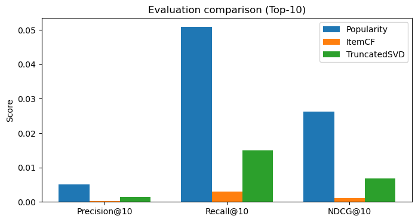

```python
metrics = ["Precision@10", "Recall@10", "NDCG@10"]
methods = results.index.tolist()

x = np.arange(len(metrics))
width = 0.25

plt.figure(figsize=(8, 4))
for i, m in enumerate(methods):
    plt.bar(x + i*width, results.loc[m, metrics].values, width, label=m)

plt.xticks(x + width, metrics)
plt.title("Evaluation comparison (Top-10)")
plt.ylabel("Score")
plt.legend()
plt.show()
```

## Recommendation demo outputs

Selecting a valid user from the training data and printing Top-10 results.

```python
#Checking how many valid user_ids are there for testing the recommender
print("Valid user_ids (in interaction_matrix):", interaction_matrix.index.nunique())
```

```
Valid user_ids (in interaction_matrix): 1772
```

```python
demo_user = interaction_matrix.index[0]
print("Demo user id:", demo_user)

pop = recommend_popularity(demo_user, 10)
itemcf = recommend_itemcf_user(demo_user, 10)
svdrec = recommend_svd_user(demo_user, 10)

print("\nPopularity baseline (Top 10):")
for a in (pop or []):
    print("-", asin_to_product.get(a, a))

print("\nItem similarity (Top 10):")
for a in (itemcf or []):
    print("-", asin_to_product.get(a, a))

print("\nTruncatedSVD (Top 10):")
for a in (svdrec or []):
    print("-", asin_to_product.get(a, a))
```

```
Demo user id: AE23NAHINBRGBQ3A46YME3TPRL3A

Popularity baseline (Top 10):
- Fire TV Stick with Alexa Voice Remote, streaming media player - Previous Generation
- Echo Dot (2nd Generation) - Smart speaker with Alexa - White
- Fire Tablet with Alexa, 7" Display, 16 GB, Blue - with Special Offers (Previous Generation - 5th)
- Panasonic ErgoFit Wired Earbuds, In-Ear Headphones with Microphone and Call Controller, Ergonomic Custom-Fit Earpieces (S/M/L), 3.5mm Jack for Phones and Laptops - RP-TCM125-A (Blue)
- Fire TV Stick 4K streaming device with Alexa Voice Remote (includes TV controls) | Dolby Vision
- Fire TV Stick streaming device with Alexa built in, includes Alexa Voice Remote, HD, latest release
- Amazon Smart Plug, for home automation, Works with Alexa - A Certified for Humans Device
- OontZ Angle 3 Bluetooth Speaker, Portable Wireless Bluetooth 5.0 Speaker, 10 Watts, Crystal Clear Stereo Sound, Rich Bass, IPX5 Water Resistant, Loud Portable Bluetooth Speaker (Black)
- Echo Dot (3rd Gen, 2018 release) - Smart speaker with Alexa - Charcoal
- Seagate Expansion 16TB External Hard Drive HDD - USB 3.0, with Rescue Data Recovery Services (STKP16000402)

Item similarity (Top 10):
- Fire TV Stick streaming device with Alexa built in, includes Alexa Voice Remote, HD, latest release
- Digital Photo Frame 15-inch WiFi Digital Picture Frame - FULLJA Smart Digital Photo Frames 32GB Storage, Easy to Setup and Share Photos and Videos via App or Email, Gifts for Family
- (2020 Latest, Backlit) ANEWISH 2.4GHz Mini Wireless Keyboard with Touchpad Mouse Combo, Rechargable Li-ion Battery & Multi-media Handheld Remote for Google Android TV Box,PS3,PC,PAD (T16-BLUE)
- Betron BS10 Earphones Wired Headphones in Ear Noise Isolating Earbuds with Microphone and Volume Control Powerful Bass Driven Sound, 12mm Large Drivers, Ergonomic Design
- Garmin 010-01769-01 Vivoactive 3, GPS Smartwatch with Contactless Payments and Built-In Sports Apps, Black with Silver Hardware
- NuForce Optoma BE2 Wireless Bluetooth Earphones with Patented SpinFit eartips, 10h Battery, Microphone, AAC Support for iPhone
- SABRENT Rechargeable Ergonomic 2.4GHz Wireless Mouse with 4D Function (MS-WRCH)
- SanDisk Extreme 256GB microSDXC UHS-I Card with Adapter - SDSQXAO-256G-GN6MA
- 40W 12V 3.33A AC Laptop Power Charger for Samsung 11.6" Chromebook Xe303c12, XE303C12-A01,Chromebook 2 3 Xe500c12(Not Compatible with Samsung ATIV laptops XE500C21, XE550C22, XE700T1A)
- KROSER Laptop Backpack 15.6 Inch Stylish Backpack Doctor Bag Water Repellent College Casual Daypack with USB Port Travel Business Work Bag for Men/Women-Black

TruncatedSVD (Top 10):
- Echo Dot (2nd Generation) - Smart speaker with Alexa - White
- Fire Tablet with Alexa, 7" Display, 16 GB, Blue - with Special Offers (Previous Generation - 5th)
- Fire TV Stick streaming device with Alexa built in, includes Alexa Voice Remote, HD, latest release
- Fire HD 10 Tablet with Alexa Hands-Free, 10.1" 1080p Full HD Display, 32 GB, Marine Blue (Previous Generation - 7th)
- Kindle Paperwhite E-reader (Previous generation – 2015 release) - Black, 6" High-Resolution Display (300 ppi) with Built-in Light, Wi-Fi, Ad-Supported
- Kindle Paperwhite – (previous generation - 2018 release) Waterproof with 2x the Storage – Ad-Supported
- Echo Dot (3rd Gen, 2018 release) - Smart speaker with Alexa - Charcoal
- Hercules Wireless Bluetooth Speaker (White/Green)
- Amazon Basics USB-A to USB-B 2.0 Cable for Printer or External Hard Drive, Gold-Plated Connectors, 10 Foot, Black
- Anker [3-Pack Powerline Micro USB Cable (3ft), Charging Cable for Micro Port E-Readers and More Micro USB Devices(Black)
```

```python
print("List of Valid user_ids:")
for uid in interaction_matrix.index[:10]:
    print(f"- {uid}")
```

```
List of Valid user_ids:
- AE23NAHINBRGBQ3A46YME3TPRL3A
- AE24GJD7LU2CDYQLP6PYTC3XZNAA
- AE2AS2F5NTZQDAZ6S7D2XG6Q7KAA
- AE2BLXPEH643OUNYUROLEJOHCMWQ
- AE2CJPQPEGCIDJKZZRYDSVRV46SA
- AE2CO6MCKFITWP2QMMS2HZAVXD7A
- AE2FQQXVDPDS7CYYO4DTBTOTNSCQ
- AE2MIK6YBTBRNZZGI5O5Z6VCMEPA
- AE2NFMTZ74ACGAWI5CMVOXZGLUUQ
- AE2ODQD5CBSZKNZLJCDKZFYKOTEQ
```

## Notebook CLI input section

- User input for Top-N recommendations
- Cold-start fallback message when user is unknown or has no history (Popularity Baseline)

```python
## Printing recommended products by converting ASIN codes into readable product names
def print_recs(title, asins):
    print(f"\n{title}")
    for a in asins:
        print("->", asin_to_product.get(a, a))


# Implementing a simple notebook CLI for user-based Top-N recommendations
def run_cli():
    while True:
        # Asking the user to choose between generating recommendations or quitting
        choice = input("\nChoose: 1) Recommend for user  2) Quit: ").strip()

        # Quitting the CLI loop when option 2 is selected
        if choice == "2":
            print("Exited")
            break

        # Handling invalid menu options
        if choice != "1":
            print("Invalid choice. Type 1 or 2.")
            continue

        # Taking user_id input for generating personalized recommendations
        user_id = input("Enter user_id: ").strip()

        # Generating recommendations using Item–Item similarity (ItemCF)
        itemcf = recommend_itemcf_user(user_id, 10)

        # Generating recommendations using TruncatedSVD (latent factor model)
        svdrec = recommend_svd_user(user_id, 10)

        # Handling cold-start or unknown user by falling back to popularity baseline
        if (user_id not in interaction_matrix.index) or (itemcf is None and svdrec is None):
            print("\nNo interaction history or unknown user. Recommending Top-N popular items (Popularity baseline).")
            pop = recommend_popularity(user_id, 10)
            print_recs("Popularity baseline (Top 10):", pop)
            continue

        # Displaying Item–Item similarity recommendations when available
        if itemcf is None:
            print("\nItem–Item similarity: Cold-start (no history available).")
        else:
            print_recs("Item–Item similarity (Top 10):", itemcf)

        # Displaying TruncatedSVD recommendations when available
        if svdrec is None:
            print("\nTruncatedSVD: Unknown user_id (not in training data).")
        else:
            print_recs("TruncatedSVD (Top 10):", svdrec)


# Running the notebook CLI for interacting with the recommendation system
run_cli()
```

```
Invalid choice. Type 1 or 2.
```

```
No interaction history or unknown user. Recommending Top-N popular items (Popularity baseline).

Popularity baseline (Top 10):
-> Fire TV Stick with Alexa Voice Remote, streaming media player - Previous Generation
-> Echo Dot (2nd Generation) - Smart speaker with Alexa - White
-> Fire Tablet with Alexa, 7" Display, 16 GB, Blue - with Special Offers (Previous Generation - 5th)
-> Panasonic ErgoFit Wired Earbuds, In-Ear Headphones with Microphone and Call Controller, Ergonomic Custom-Fit Earpieces (S/M/L), 3.5mm Jack for Phones and Laptops - RP-TCM125-A (Blue)
-> Fire TV Stick 4K streaming device with Alexa Voice Remote (includes TV controls) | Dolby Vision
-> Fire TV Stick streaming device with Alexa built in, includes Alexa Voice Remote, HD, latest release
-> Amazon Smart Plug, for home automation, Works with Alexa - A Certified for Humans Device
-> OontZ Angle 3 Bluetooth Speaker, Portable Wireless Bluetooth 5.0 Speaker, 10 Watts, Crystal Clear Stereo Sound, Rich Bass, IPX5 Water Resistant, Loud Portable Bluetooth Speaker (Black)
-> Echo Dot (3rd Gen, 2018 release) - Smart speaker with Alexa - Charcoal
-> Seagate Expansion 16TB External Hard Drive HDD - USB 3.0, with Rescue Data Recovery Services (STKP16000402)
```

```
Item–Item similarity (Top 10):
-> DUCLUS Mini Photo Studio Light Box,Portable Folding Photography Light Tent kit with 40pcs LED Light + 6 Kinds Color Backgrounds for Small Size Products
-> 2-Year Protection Plan plus Accident Protection for Kindle Paperwhite (6th Generation)
-> Lifeproof FRĒ SERIES iPhone 6/6s Waterproof Case (4.7" Version) - Retail Packaging - SUNSET (PIPELINE/WINDSURF/LONGBOARD)
-> UGREEN Headphone Splitter for Computer 3.5mm Female to 2 Dual 3.5mm Male Braided Audio Splitter Cable Microphone Stereo Jack Earphones Port Cord Gaming Headset to PC Laptop Adapter Black
-> New Balance Laptop Backpack, Legacy Travel Bag for Men and Women, Black and Red, One Size
-> Photo Backdrop Board with 3 Brackets 2PCS Double-Sided Food Photography backdrops for Jewelry Cosmetics Product Photography 24 * 24in
-> Nikon COOLPIX L830 16 MP CMOS Digital Camera with 34x Zoom NIKKOR Lens and Full 1080p HD Video (Black) (Discontinued by Manufacturer)
-> StarTech.com 7 Port USB C Hub with Fast Charge Port - USB-C to 5X USB-A 2X USB-C (USB 3.0 SuperSpeed 5Gbps) - Self Powered USB 3.1 Gen 1 Type-C Hub w/Power Adapter - Desktop/Laptop Hub (HB30C5A2CSC)
-> Rapid Type C Car Charger, 30W Mini Flush Fit Car Charge Compatible for Google Pixel 3a XL/3a/3/2 XL/2/XL/C, Aluminum Alloy Fast Car Adapter, Dual Port Fast Charger with 6.6 ft Type C Cord
-> Amazon 5ft USB to Micro-USB Cable (designed for use with Fire tablets and Kindle E-readers)

TruncatedSVD (Top 10):
-> Panasonic ErgoFit Wired Earbuds, In-Ear Headphones with Microphone and Call Controller, Ergonomic Custom-Fit Earpieces (S/M/L), 3.5mm Jack for Phones and Laptops - RP-TCM125-A (Blue)
-> SABRENT 10 Port 60W USB 3.0 Hub with Individual Power Switches and LEDs Includes 60W 12V/5A Power Adapter (HB-BU10)
-> Cat 6 Ethernet Cable 1 Ft (6Pack), Outdoor&Indoor, 10Gbps Support Cat7 Network, Heavy Duty Flat Internet LAN Patch Cord, Solid High Speed Weatherproof Cable for Router, Modem, Xbox, PS4, Switch, Black
-> JSAUX USB-C to USB A Cable 3.1A Fast Charging [2-Pack 6.6ft], USB Type C Charger Cord Compatible with Samsung Galaxy S10 S9 S8 S20 Plus A51 A12 A11, Note 10 9 8, PS5 Controller USB C Charger-Green
-> SAMSUNG (MB-ME64GA/AM) 64GB 100MB/s (U3) MicroSDXC EVO Select Memory Card with Full-Size Adapter
-> Samsung 32GB up to 48MB/s EVO Class 10 Micro SDHC Card with Adapter (MB-MP32DA/AM)
-> SanDisk 128GB Ultra Fit USB 3.1 Flash Drive - SDCZ430-128G-G46, Black
-> Fire TV Stick 4K streaming device with Alexa Voice Remote (includes TV controls) | Dolby Vision
-> Crucial MX500 1TB 3D NAND SATA 2.5 Inch Internal SSD, up to 560MB/s - CT1000MX500SSD1
-> SanDisk 32GB Class 4 SDHC Memory Card, Frustration-Free Packaging- SDSDB-032G-AFFP (Label May Change)
```

```
Exited
```